# Censored and Truncated Data

João Neto

October 2015

Refs:

- Spiegelhalter et al - The Bugs Book (2013)
- MacKay - Information Theory, Inference & Learning Algs (2003)
- Stan 2.8 user and reference guide (2015)

This tutorial uses probabilistic programming to deal with the problems of truncated and censored data, namely, using examples in BUGS, JAGS and Stan.

What’s the difference between truncated and censored data?

- *Truncated data* happens when the generating process only produces values within an interval of values. Everything below of above simply are not observed.
- *Censored data* means that some observations are censored. We know that they existed, however we are unable to know their precise values. Usually, we know if they have values below or above a certain threashold, or within a given limited interval (egs: obs < 4; obs > 7; obs $\in [4,7]$). So censored data provides more information than truncated data.

# Truncated Data

This problem appears at MacKay’s book, at the beginning of chapter 3:

> Unstable particles are emitted from a source and decay at a distance x, a real number that has an exponential probability distribution with characteristic length $\lambda$. Decay events can be observed only if they occur in a window extending from x = 1 cm to x = 20 cm. N decays are observed at locations { x_1, x_2, , x_N}. What is $\lambda$?

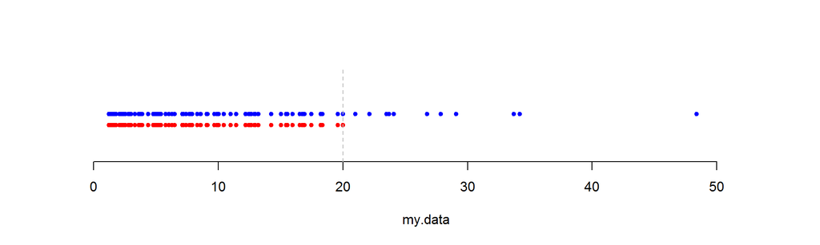

```r
library(PoweR) # includes shifted exponential distribution

N <- 100
true.lambda  <- 10
truncated.at <- 20

set.seed(141)
my.data <- gensample(12,N,law.pars=c(1,1/true.lambda))$sample # shifted exponential

my.data.tr <- my.data[my.data<truncated.at]  # truncated data

plot(my.data, rep(1,N), pch=20, col="blue", ylab="", yaxt='n', bty="n", xlim=c(0,max(my.data)+5))
points(my.data.tr, rep(0.9,length(my.data.tr)), pch=20, col="red")
abline(v=truncated.at, col="grey", lty=2)
```

## An Analytic Solution

Using MacKay’s Bayesian solution, the likelihood function for data point $x$ is

$$p(x|\lambda) =
\left\{
\begin{array}{ll}
\frac{1}{Z(\lambda)} \frac{e^{-x/\lambda}}{\lambda } & \mbox{if } 1 \leq x \lt 20 \\
0 & \mbox{if } \text{otherwise}
\end{array}
\right.$$

with

$$Z(\lambda) = \int_1^{20} \frac{e^{-x/\lambda}}{\lambda} dx = e^{-1/\lambda} - e^{-20/\lambda}$$

as the normalizing constant for a given $\lambda$.

Now, by Bayes’ Theorem, with $\mathcal{D} = \{ x_1, x_2, \ldots, x_N\}$:

$$p(\lambda | \mathcal{D}) \propto p(\mathcal{D}|\lambda) p(\lambda)$$

where $p(\lambda)$ is the chosen prior distribution for $\lambda$.

Assuming that $x_i$ are iid, ie, $p(\mathcal{D}|\lambda) = \prod_i p(x_i|\lambda)$:

$$p(\lambda | \mathcal{D}) \propto \prod_i p(x_i|\lambda) ~ p(\lambda) = \frac{1}{(\lambda Z(\lambda))^N} ~ \exp\left\{ -\sum_{i=1}^N x_i/\lambda \right\} ~ p(\lambda)$$

Let’s implement this in R:

```r
# function that returns the posterior, given data D and a prior
get.post <- function(D, prior) {
  n <- length(D)

  function(lambda) {
    Z <- exp(-1/lambda) - exp(-truncated.at/lambda)
    exp(-sum(D)/lambda)*prior(lambda) / (lambda * Z)^n
  }
}

# log version
get.log.post <- function(D, prior) {
  n <- length(D)

  function(lambda) {
    Z <- exp(-1/lambda) - exp(-truncated.at/lambda)
    (-sum(D)/lambda) + log(prior(lambda)) - n*log(lambda * Z)
  }
}
```

We need to choose a prior. Herein, we’ll use a Cauchy centered at 5 with a large scale parameter. Let’s define it, and apply it to compute the posterior distribution:

```r
prior         <- function(lambda) {dcauchy(lambda,5,25)} # define a prior
log.posterior <- get.log.post(my.data.tr, prior)         # log posterior
```

That’s it!

Let’s plot the results:

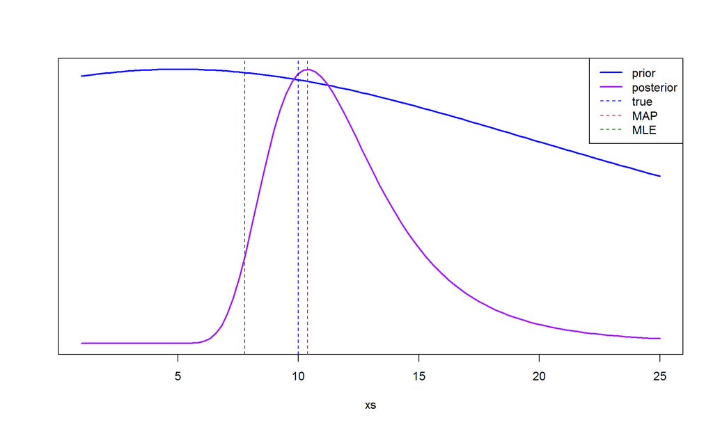

```r
xmax <- 25
xs   <- seq(1,xmax,len=100)

ys_prior <- sapply(xs, prior)
plot(xs, ys_prior, type="l", col="blue", lwd=2, ylim=c(0,max(ys_prior)), ylab="", yaxt='n')

ys_post <- sapply(xs, function(x) exp(log.posterior(x)))
ratio <- max(ys_post)/max(ys_prior)                # place them at the same y-scale
points(xs, ys_post/ratio, type="l", col="purple", lwd=2)
legend("topright", c("prior", "posterior","true", "MAP", "MLE"),
       col=c("blue", "purple", "blue", "red", "darkgreen"),
       lty=c(1,1,2,2,2), lwd=c(2,2,1,1,1))

abline(v=true.lambda, col="blue", lty=2)  # draw true value

f.optim <- function(x) -log.posterior(x)
res <- optim(10, f.optim, method="Brent", lower=0, upper=1e3)
MAP <- res$par
abline(v=MAP, col="red",  lty=2)          # draw Maximum A Posteriori estimate

# compare with the MLE
MLE <- mean(my.data.tr)                   # draw Maximum Likelihood Estimate
abline(v=MLE, col="darkgreen", lty=2)
```

If we choose a different prior like an uniform, or a Cauchy at a different location, say 10 or 15, the MAP estimate would be very similar, since there are plenty of data to ‘drown’ the prior.

## A Simulation Solution

Let’s assume an analytic solution was not possible, and try JAGS to solve this problem. I’m using JAGS given that we are dealing with a truncated distribution, and it’s easier to handle than with BUGS:

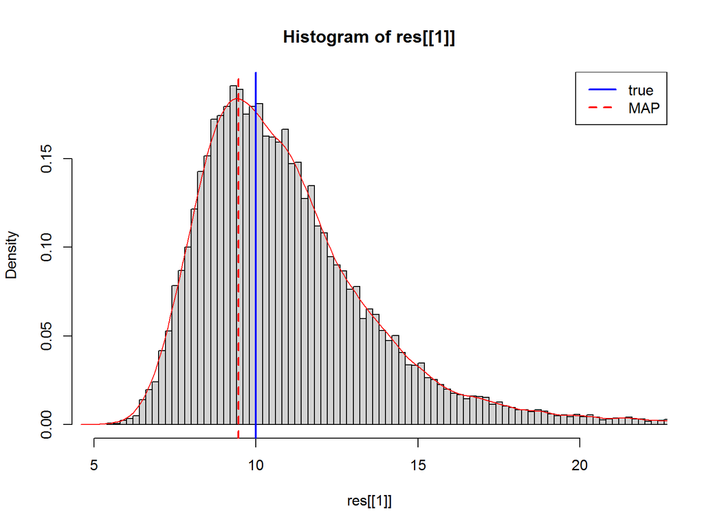

```r
library(rjags)

model = "
  model {

    for(i in 1:N) {
      x[i] ~ dexp(rate)T(1,20) # truncated exponential
    }

    rate ~ dt(0.2,0.0016,1)    # ~ Cauchy(1/0.2, (1/25)^2)
    lambda <- 1/rate
  }
"

writeLines(model, con="model.txt")  # Write the modelString to a file

jags <- jags.model("model.txt",
                   data = list('x' = my.data.tr,
                               'N' = length(my.data.tr)),
                   n.chains = 4,
                   n.adapt = 2500)
update(jags, 15000)

res <- jags.samples(jags, c('lambda'), 5000)  # get samples
hist(res[[1]], breaks=200, xlim=c(5,22), col="lightgrey", prob=TRUE)  # first chain
d <- density(res[[1]])
lines(d, col="red", lwd=1)
lambda_MAP <- d$x[which.max(d$y)]
abline(v=lambda_MAP, col="red", lty=2, lwd=2)
abline(v=true.lambda, col="blue", lwd=2)
legend("topright", c("true", "MAP"),  col=c("blue", "red"),  lty=c(1,2), lwd=2)
```

We get a MAP estimate of $\hat{\lambda} =$ 9.45 which is quite nice given the true value $\lambda =$ 10.

Also, the same model in Stan:

```r
library(rstan)

model = "
  data {
    int<lower=1> N;
    real U;
    real<upper=U> x[N];
  }

  parameters {
    real<lower=0> rate;
  }

  model {
    for (i in 1:N)
      x[i] ~ exponential(rate) T[1,U];

    rate ~ cauchy(5, 25);
  }
"

N <- length(my.data.tr)
U <- truncated.at
x <- my.data.tr

fit  <- stan(model_code = model, data = list(x=x, N=N, U=U), iter = 1e3, chains = 2, verbose = FALSE)
fit2 <- stan(fit = fit,          data = list(x=x, N=N, U=U), iter = 2e4, chains = 2, verbose = FALSE, seed=101, warmup=5000)
```

Let’s present the results:

```r
print(fit2)
```

```
## Inference for Stan model: c54ba629726984b9ce374e5a533a6169.
## 2 chains, each with iter=20000; warmup=5000; thin=1;
## post-warmup draws per chain=15000, total post-warmup draws=30000.
##
##         mean se_mean   sd    2.5%     25%     50%     75%   97.5% n_eff
## rate    0.10    0.00 0.02    0.06    0.08    0.10    0.11    0.14  8423
## lp__ -248.04    0.01 0.76 -250.19 -248.21 -247.74 -247.56 -247.50  8170
##      Rhat
## rate    1
## lp__    1
##
## Samples were drawn using NUTS(diag_e) at Tue May 24 17:49:59 2016.
## For each parameter, n_eff is a crude measure of effective sample size,
## and Rhat is the potential scale reduction factor on split chains (at
## convergence, Rhat=1).
```

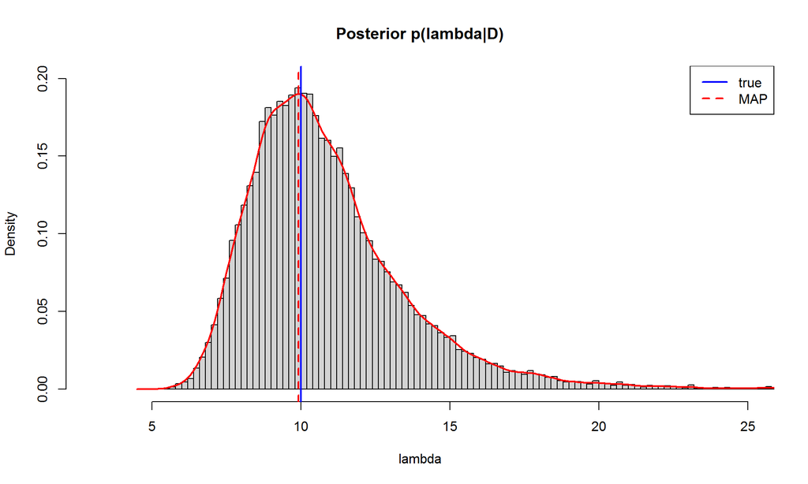

```r
la <- extract(fit2, permuted = TRUE)
hist(as.numeric(1/la$rate), breaks=200, prob=T, xlab="lambda", col="lightgrey",
     main="Posterior p(lambda|D)", xlim=c(3,xmax), ylim=c(0,0.2))
d <- density(1/la$rate)
lines(d, col="red", lwd=2)
lambda_MAP <- d$x[which.max(d$y)]
abline(v=lambda_MAP, col="red", lty=2, lwd=2)
abline(v=true.lambda, col="blue", lwd=2)
legend("topright", c("true", "MAP"),  col=c("blue", "red"),  lty=c(1,2), lwd=2)
```

## Unknown Truncation value

What if the truncation value was not known? Then, the value `U` turns out to be a parameter:

```r
model = "
  data {
    int<lower=1> N;
    real x[N];
  }

  parameters {
    real<lower = max(x)> U;
    real<lower=0> rate;
  }

  model {
    U ~ cauchy(30, 25);

    for (i in 1:N)
      x[i] ~ exponential(rate) T[1,U];

    rate ~ cauchy(5, 25);
  }
"

N <- length(my.data.tr)
x <- my.data.tr

fit  <- stan(model_code = model, data = list(x=x, N=N), iter = 1e3, chains = 2, verbose = FALSE)
fit2 <- stan(fit = fit,          data = list(x=x, N=N), iter = 2e4, chains = 4, verbose = FALSE, seed=101, warmup=5000)
```

We can see that the estimated mean of `U` is near the true value of 20 (even considering that the true value is not (barely) inside the 95% confidence interval), while the mode (50% quantile) is closer:

```r
print(fit2)
```

```
## Inference for Stan model: 3a0b08c357f376845c623fee5f2c33ff.
## 4 chains, each with iter=20000; warmup=5000; thin=1;
## post-warmup draws per chain=15000, total post-warmup draws=60000.
##
##         mean se_mean    sd    2.5%     25%     50%     75%   97.5% n_eff
## U      22.23    0.26 39.21   20.01   20.22   20.56   21.22   26.66 23422
## rate    0.10    0.00  0.02    0.06    0.09    0.10    0.12    0.15 19319
## lp__ -250.11    0.01  1.14 -253.11 -250.57 -249.76 -249.29 -249.00 13356
##      Rhat
## U       1
## rate    1
## lp__    1
##
## Samples were drawn using NUTS(diag_e) at Tue May 24 17:51:10 2016.
## For each parameter, n_eff is a crude measure of effective sample size,
## and Rhat is the potential scale reduction factor on split chains (at
## convergence, Rhat=1).
```

Also, the posterior mean value and mode of `rate` corresponds exactly to the value of $\lambda$ (notice that `rate == 1/lambda`).

Check chapter 8 in Stan’s [reference guide](http://mc-stan.org/documentation/) for more information.

# Censored Data

The available data:

```r
my.data.cn <- c(6,6,6,7,7,7,8,8,8)  # 8 means 8+
```

For censored data, BUGS is able to use suffix `C`, after the censored data distribution, to denote the known limits for those values. In this case, the last three values are censored in the open interval $[8,+\infty)$, so we use `C(8,)`:

```r
modelString = "
  model {
    for (i in 1:6) {
      x[i] ~ dnorm(mu, 1)      # uncensored data
    }
    for (i in 7:9) {
      x[i] ~ dnorm(mu, 1)C(8,) # censored data
    }

    mu ~ dunif(0, 100)
  }
"

my.data.cn[my.data.cn==8] <- NA # convert 8 to NA

data.list = list(
  x = my.data.cn
)

run.model(modelString, samples=c("mu", "x[7]"), data=data.list, chainLength=10000)
```

```
## model is syntactically correct
```

```
## data loaded
```

```
## model compiled
```

```
## 1000 updates took 0 s
```

```
## monitor set for variable 'mu'
```

```
## monitor set for variable 'x[7]'
```

```
## 10000 updates took 0 s
```

```r
samplesStats(c("mu", "x[7]"))  # x[8] & x[9] same as x[7]
```

```
##       mean     sd MC_error val2.5pc median val97.5pc start sample
## mu   7.191 0.3447 0.003781    6.519  7.194     7.860  1001  10000
## x[7] 8.575 0.4771 0.004717    8.019  8.456     9.768  1001  10000
```

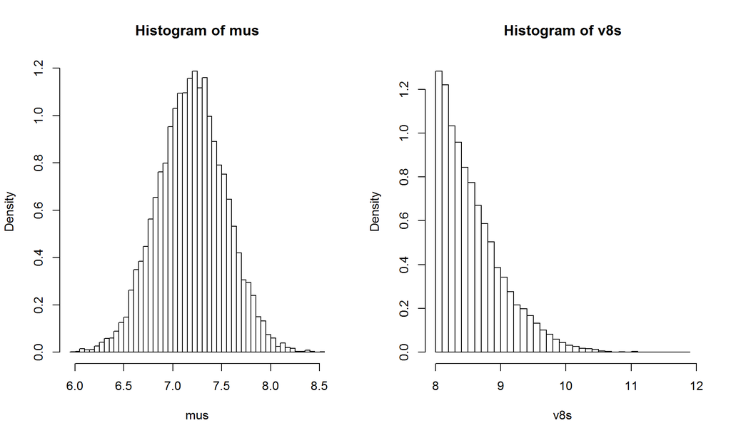

```r
mus <- samplesSample("mu")
v8s <- samplesSample("x[7]")   # samples for values equal to 8

par(mfrow=c(1,2))
hist(mus, breaks=50, prob=T)
hist(v8s, breaks=50, prob=T)
```

## Interval censoring

Another type of censoring occurs when the data was rounded before the analysis. So, for instance, a 8 might mean any value between $[7.5, 8.5]$.

```r
my.data2.cn <- c(6,6,6,7,7,7,8,8,8)
N <- length(my.data2.cn)
```

The model in JAGS uses the `dinterval` distribution for censored data. Writing `y ~ dinterval(x1,x2)`, where `x2` is a vector of two values, means one of three options:

- `y==0` if `x1 <= x2[1]`
- `y==1` if `x2[1] < x1 <= x2[2]`
- `y==2` if `x1 > x2[2]`

So, to use this in our eg, we first define the limits for each data point:

```r
lim <- cbind(my.data2.cn-0.5, my.data2.cn+0.5)  # intervals for each data point
lim
##       [,1] [,2]
##  [1,]  5.5  6.5
##  [2,]  5.5  6.5
##  [3,]  5.5  6.5
##  [4,]  6.5  7.5
##  [5,]  6.5  7.5
##  [6,]  6.5  7.5
##  [7,]  7.5  8.5
##  [8,]  7.5  8.5
##  [9,]  7.5  8.5
```

and we will force the vector `y` that will appear in our model, to be all made of 1’s, so that every data point falls inside its interval:

```r
y <- rep(1,N)
```

The model becomes:

```r
model = "
  model {
    for (i in 1:N) {
      y[i] ~ dinterval(x[i], lim[i,])

      x[i] ~ dnorm(mu, 1)
    }

    mu ~ dnorm(0,1E-6)
  }
"

writeLines(model, con="model.txt")  # Write the modelString to a file

jags <- jags.model("model.txt",
                   data = list(x   = rep(NA,N),
                               N   = N,
                               lim = lim,
                               y   = y),
                   n.chains = 4,
                   inits= list(mu = 5,
                               x  = as.vector(apply(lim,1,mean))), # initial vals
                   n.adapt = 2500)
update(jags, 25000)
res <- jags.samples(jags, c('mu', 'x[1]', 'x[4]', 'x[7]'), 5000)
summary(as.mcmc.list(res$mu))
```

```
##
## Iterations = 1:5000
## Thinning interval = 1
## Number of chains = 4
## Sample size per chain = 5000
##
## 1. Empirical mean and standard deviation for each variable,
##    plus standard error of the mean:
##
##           Mean             SD       Naive SE Time-series SE
##       6.997411       0.346840       0.002453       0.002644
##
## 2. Quantiles for each variable:
##
##  2.5%   25%   50%   75% 97.5%
## 6.324 6.768 6.998 7.227 7.678
```

```r
summary(as.mcmc.list(res$`x[1]`))
```

```
##
## Iterations = 1:5000
## Thinning interval = 1
## Number of chains = 4
## Sample size per chain = 5000
##
## 1. Empirical mean and standard deviation for each variable,
##    plus standard error of the mean:
##
##           Mean             SD       Naive SE Time-series SE
##       6.078613       0.276564       0.001956       0.001955
##
## 2. Quantiles for each variable:
##
##  2.5%   25%   50%   75% 97.5%
## 5.545 5.861 6.110 6.318 6.482
```

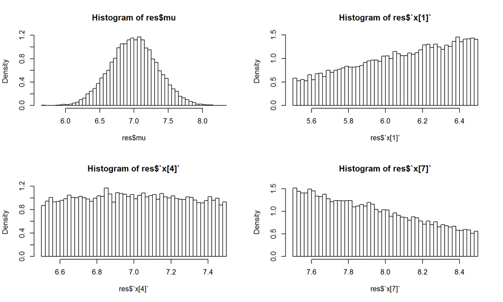

```r
par(mfrow=c(2,2))
hist(res$mu,     breaks=50, prob=T)
hist(res$`x[1]`, breaks=50, prob=T)
hist(res$`x[4]`, breaks=50, prob=T)
hist(res$`x[7]`, breaks=50, prob=T)
```

We notice a shrinkage towards the mean, since all the measures share the same normal distribution.

The BUGS model for the same problem would be like this:

```r
modelString = "
  model {
    for (i in 1:9) {
      lower[i] <- x[i] - 0.5
      upper[i] <- x[i] + 0.5

      z[i] ~ dnorm(mu, 1)I(lower[i], upper[i])
    }

    mu ~ dunif(0, 100)
  }
"
```

… but somehow the compilation process does not work (?)